# Geopython basics

This is a whirlwind tour of the basics of Python. In this notebook I will introduce you to the main data types you will encounter in Python, a few of the main packages you will use to manipulate data and the basics of making plots. There are tons of resources for learning the basics of Python, so if you want to know more - Youtube, ChatGPT, and Google are your friend. You should be able to follow this even if you have little to no programming experience, but I have created this with R users looking to get to grips with Python in mind

# Notebooks

We will use Jupyter notebooks and Google colab here. Notebooks are a great way to mix executable code with rich content (HTML, images, equations written in LaTeX). Colab allows us to run notebooks on the cloud for free without any prior installation. Many of the commonly used packages for data science in Python are pre-installed in colab. In the next session we will run Jupyter notebooks on our own computer, but this requires some setup.

In Jupyter/Colab the output of the last line in a cell is printed, unless you wrap the command in `print()`, in which case it can appear anywhere

```python
1
2
```

```python
print(1)
print(2)
```

# Python core data types

## Arithmetic operations

Python supports the usual arithmetic operators: + (addition), * (multiplication), / (division), ** (power), // (integer division).

## Lists

Lists are a container type for ordered sequences of elements. They are declared inside square brackets `[]`. Lists can be initialized empty

```python
my_list = []
```

or with some initial elements

```python
my_list = [1, 2, 3]
```

Lists have a dynamic size and elements can be added (appended) to them

```python
my_list.append(4)
my_list
```

We can access individual elements of a list (indexing starts from 0)

```python
my_list[2]
```

We can access “slices” of a list using `my_list[i:j]` where `i` is the start of the slice (again, indexing starts from 0) and `j` the end of the slice. For instance:

```python
my_list[0:2]
```

Omitting the second index means that the slice shoud run until the end of the list

```python
my_list[1:]
```

We can check if an element is in the list using `in`

```python
5 in my_list
```

The length of a list can be obtained using the `len` function

```python
len(my_list)
```

## Strings

Strings are used to store text. They can delimited using either single quotes or double quotes

```python
string1 = "some text"
string2 = 'some other text'
```

Strings behave similarly to lists. As such we can access individual elements in exactly the same way

```python
string1[3]
```

and similarly for slices

```python
string1[5:]
```

String concatenation is performed using the `+` operator

```python
string1 + " " + string2
```

f-strings are a convinient way to insert variables into strings

```python
f'this is the list I created earlier {my_list}. neat'
```

## Dictionaries

In Python, a dictionary is a built-in data structure that stores a collection of key-value pairs. Dictionaries are indexed by unique keys. Keys and values can be strings or numeric data types. Dictionaries are declared in curly brackets `{}`

Here’s a basic example of a dictionary in Python:

```python
# Creating a dictionary
student = {
    "name": "John",
    "age": 20,
    "degree": "B.Sc"
}

# Accessing values using keys
print(student["name"])
print(student["age"])
```

## Conditionals

As their name indicates, conditionals are a way to execute code depending on whether a condition is True or False. As in other languages, Python supports `if` and `else` but `else if` is contracted into `elif`, as the example below demonstrates.

```python
my_variable = 5
if my_variable < 0:
  print("negative")
elif my_variable == 0:
  print("null")
else: # my_variable > 0
  print("positive")
```

Here `<` and `>` are the strict `less` and `greater than` operators, while `==` is the equality operator (not to be confused with `=`, the variable assignment operator). The operators `<=` and `>=` can be used for less (resp. greater) than or equal comparisons.

Contrary to other languages, blocks of code are delimited using indentation. Here, we use 2-space indentation but many programmers also use 4-space indentation. Any one is fine as long as you are consistent throughout your code.

## Loops

Loops are a way to execute a block of code multiple times. There are two main types of loops: while loops and for loops.

While loop

```python
i = 0
while i < len(my_list):
  print(my_list[i])
  i += 1 # equivalent to i = i + 1
```

For loop

```python
for i in range(len(my_list)):
  print(my_list[i])
```

If the goal is simply to iterate over a list, we can do so directly as follows

```python
for element in my_list:
  print(element)
```

## Functions

To improve code readability, it is common to separate the code into different blocks, responsible for performing precise actions: functions. A function takes some inputs and process them to return some outputs.

```python
def square(x):
  return x ** 2

def multiply(a, b):
  return a * b

# Functions can be composed.
square(multiply(3, 2))
```

To improve code readability, it is sometimes useful to explicitly name the arguments

```python
square(multiply(a=3, b=2))
```

## Classes and Object Oriented Programming

Something that you may not have encountered yet is the concept of Object Oriented Programming. Object-Oriented Programming (OOP) is a way to write programs using “objects”, which bundle related data and operations.

**Classes:** Think of them as blueprints for creating similar objects. An example might be a Person class or a Dog class

**Objects:** These are individual instances of a class. They have specific data (like a person’s name) and can perform operations (like a person walking). An example would be Glenn - an object of the Person class, or Murray - an object of the dog class

In OOP, you create instances from classes, similar to making houses from blueprints. When we define the class we can give it attributes and methods.

Let see what this looks like in concete term by defing a dog class

```python
class Dog

    #__init__ is run when we create an object of this class
    # here we can pass variables when creating an object after the mandatory 'self' argument
    def __init__(self, name):
        self.name = name  # set an attribute using self.attribute

    # create a method that belongs to this class using def
    # the first argument must be self
    def bark(self):
        return "Woof!"
```

```python
# Now, let's create an instance of the class Dog
# This runs the __init__ function
my_dog = Dog("Murray")
```

The `my_dog` instance has a single attribute - his name, Murray (a fine name for a dog). We set this in the `__init__` method using `self.name =`. We can access the attributes of an instance using the pattern `object.attribute`

```python
my_dog.name
```

`my_dog` has a single method - `bark()`. We can access a class’ method using the pattern `instance.method()`. Methods and functions are the same thing. A method is just a function that belongs to an instance

```python
my_dog.bark()
```

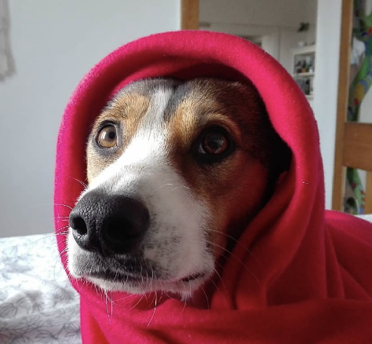

## Importing packages

A Python package is a collection of related Python scripts, called modules. Modules usually contain functions and classes that we will reuse.

For example, `import math` lets you use functions and classes in the `math` module, like `math.sqrt(4)` to get the square root of 4.

```python
import math

math.sqrt(4)
```

You can import specific items from a module with `from ... import ...`, like `from math import sqrt` and then use `sqrt(4)` directly.

```python
from math import sqrt
sqrt(4)
```

You can also nickname modules when importing to make them quicker to type, like import `numpy as np`. Now you can use numpy’s functions with the prefix `np.` instead of `numpy.`

You can import all the functions in module using `from ... import *`, like `from math import *`, similar to how things are done in R. This is strongly discouraged in Python

```python
#dont do this
from math import *
sqrt(4)
```

```python
#I told you not to do that!
```

# Built-in functions, imported functions and methods that belong to classes

Something that confused me when I was moving from R to Python was the difference between built-in functions, imported functions and class instance methods

In R many of the functions and classes that you use will be built-in  
e.g `c() mean() rnorm()`  
You can also import additional methods through packages  
e.g `library(readr); read_csv('somefile.csv')`

Python has very few built in functions and classes. We have seen a few already `len() list()`, but most most be imported from external packages.  
e.g import a function

```python
from math import sqrt
sqrt(4)
```

e.g. import a class

```python
#OrderedDict is a spectial kind of python dictionary that remembers the order that keys were first inserted
from collections import OrderedDict
od = OrderedDict({'a':1,'b':2,'c':3})
od
```

In Python methods are often accessed through a class instance. Refer back the the Dog class we created above. We have the class `Dog`, and an instance of that class called `my_dog`. the method `bark()` can only be accessed through the instance using `my_dog.bark()`. Here is a concrete example using the `list` class. Remeber `list()` is built-in so we dont need to import it

```python
#list if the class, new_list an instance of class list

new_list = list([1,2,3,4])
```

```python
#lists have a number of methods

new_list.append(5)
new_list
```

# Brackets

We have now seen all the ways to use brackets in Python. Lets recap this as it is important to note the differences to other langauges

### Square brackets `[]`

We use square brackets when indexing a list or numpy array

```python
my_list[0:2]
```

or when creating a list

```python
newlist = [1,2,3]
```

### Round brackets `()`

We use round bracets when calling a function or a method

```python
len(newlist)
newlist.append(4)
```

or when creating a type of object called a Tuple, which is basically an ordered, unchangeble list

```python
mytuple = (1,2,3)
```

```python
#we cant change this
mytuple[0] = 4
```

### Curly brackets `{}`

Curly brackets are used when creating dictionaries (and sets, which you can ignore for now)

```python
another_dict = {"one":1,"two":2,"three":3}
```

# Info about objects and functions

You can find out the type of any object in Python using the built-in `type()` function

```python
type(new_list)
```

You can print out the documentation for a function with the built-in `help()` function

```python
help(sqrt)
```

You can also print out info about an exisiting object. This will list all the methods and attributes that the object has.

```python
help(new_list)
```

# NumPy

NumPy is a popular library for storing arrays of numbers and performing computations on them. Not only does it enable writing more succinct code, it also makes the code faster, since most NumPy routines are implemented in C for speed.

Numpy is probably the most important package for doing data science and scientific analysis in Python. It is very powerful and is often the basis for other packages that add additional complexity (it is at the core of all raster handling packages in python)

To use NumPy in your program, you need to import it as follows

```python
import numpy as np
```

## Array creation

NumPy arrays can be created from Python lists

```python
my_array = np.array([1, 2, 3])
my_array
```

NumPy supports arrays of arbitrary dimension. For example, we can create two-dimensional arrays (e.g. to store a matrix) as follows

```python
my_2d_array = np.array([[1, 2, 3], [4, 5, 6]])
my_2d_array
```

We can access individual elements of a 2d-array using two indices as indexing works just like for Python lists

```python
# index using:
# position_in_dim1, position_in_dim2
my_2d_array[1, 2]
```

We can also access rows

```python
my_2d_array[1]
```

and columns

```python
my_2d_array[:, 2]
```

a bare index of `:` means give me everything in that dim

```python
print(my_2d_array[:, :])
#is the same as
print(my_2d_array)
```

Arrays have a `shape` attribute

```python
print(my_array.shape)
print(my_2d_array.shape)
```

Contrary to Python lists, NumPy arrays must have a type and all elements of the array must have the same type.

```python
my_array.dtype
```

The main types are `int32` (32-bit integers), `int64` (64-bit integers), `float32` (32-bit real values) and `float64` (64-bit real values).

The `dtype` can be specified when creating the array

```python
my_array = np.array([1, 2, 3], dtype=np.float64)
my_array.dtype
```

We can create arrays of all zeros using

```python
zero_array = np.zeros((2, 3))
zero_array
```

and similarly for all ones using `ones` instead of `zeros`.

We can create a range of values using

```python
np.arange(5)
```

or specifying the starting point

```python
np.arange(3, 5)
```

Another important operation is `reshape`, for changing the shape of an array

```python
my_array = np.array([1, 2, 3, 4, 5, 6])
my_array.reshape(3, 2)
```

Play with these operations and make sure you understand them well.

## Basic operations

In NumPy, we express computations directly over arrays. This makes the code much more succint.

Arithmetic operations can be performed directly over arrays. For instance, assuming two arrays have a compatible shape, we can add them as follows

```python
array_a = np.array([1, 2, 3])
array_b = np.array([4, 5, 6])
array_a + array_b
```

NumPy has a range of functions that can be applied to arrays, e.g. `np.sin`

```python
np.sin(array_a)
```

Vector inner product can be performed using `np.dot`

```python
np.dot(array_a, array_b)
```

numpy arrays also have their own methods e.g matrix transpose `.transpose()`

```python
array_a.transpose()
```

## Slicing and masking

Like Python lists, NumPy arrays support slicing

```python
z = np.arange(10)
# you can read this as:
# start at the 5th postion and give me everything from there until the end of that dim
print(z[5:])
# you can read this as:
# start at the beggining and give me everything until the 5th position
print(z[:5])
```

We can also select only certain elements from the array

```python
x = np.arange(10)
mask = x >= 5
x[mask]
```

Because numpy arrays can have many dimensions, indexing can get quite complicated. If you want to know more have a look at the docs [here](https://numpy.org/doc/stable/user/basics.indexing.html). Lets look at what this looks like on a 3D array

```python
# Create a 3D array with values ranging from 0 to 269 with shape 3x3x30.
array_3d = np.arange(270).reshape(3, 3, 30)
array_3d
```

Lets pretend that this array has dimension latitude, longitude and band (3x3x30). Now lets extract a spatial subset - we only want the first 2x2 lat long grid with all wavelengths

```python
#dimensions separated by comma
#1st dim - :2 indicates we want everything up to the 2nd coordinate i.e 0 and 1. Writing 0:2 would be equivalent
#2nd dim - sanme as above
#3rd dim -  : a bare semicolon indicate we want all entires in that dimension
sliced_array = array_3d[:2, :2, :]
sliced_array
```

```python
sliced_array.shape
```

# Pandas

Pandas is the Python library used for tabular data manipulation and analysis. It is **very** widely used. It is the Python version of dplyr, tidyr and readr rolled into one.

Here’s an example of loading a DataFrame from a CSV file:

```python
import pandas as pd

# Load data from a CSV file into a DataFrame
df = pd.read_csv('https://gist.githubusercontent.com/curran/a08a1080b88344b0c8a7/raw/0e7a9b0a5d22642a06d3d5b9bcbad9890c8ee534/iris.csv')

# Display the first 5 rows of the DataFrame
print(df.head())
```

There are lots and lots of tutorial on how to wrnagle data with pandas. I will just show you some basics

### Indexing

Or how to select particular rows and columns

```python
# Accessing a column
print(df['sepal_length'])

# use .loc to access a row by label
print(df.loc[0])

# use .iloc to access a row by integer index
print(df.iloc[0])
```

#### Filtering

or selecting rows by a logical condition

```python
# Filter rows where 'sepal_length' is greater than 5
filtered = df[df['sepal_length'] > 5]

#what is happening here is that df['sepal_length'] > 5 is creating a series of True/False values based on the condition
#this is then used to retrun rows where the series is True

print(filtered)
```

another way of achieving the same thing is using `query`

```python
filtered = df.query('sepal_length > 5')

print(filtered)
```

#### Grouping and aggregation

```python
# Group data by the values in 'species' and compute the mean of the other columns for each group
grouped = df.groupby('species').mean()
print(grouped)
```

```python
# or maybe we just want the aggregation of a single colmn
petal_grouped = df.groupby('species')['petal_length'].mean()
print(petal_grouped)
```

#### Chaining functions

We can chain things together if we enclose the entire chain in brackets (like the `%>%` or `|>` R pipe operator). You need to think of this a little different from the R operator.  
In R, the pipe operator passes the results coming from the left side as the first argument to the function on it’s right side.  
In Python, there is no explicit pipe, but we are able to call all of the methods of an instance using `.` even if we have not assigned it yet

```python
#first assign the result
result_temp = df.groupby('species')
#then call its mean() method
result = result_temp.mean()
```

is the same as

```python
#we can use the .mean() method without explicitly assinging the result of the preceding function
#the trick is that you have to know the the type/class of the first function is to know what methods it has
#but with pandas the results are usually another dataframe
result = df.groupby('species').mean()
```

Lets see how we could use this to chain many things together

```python
#lets do everything above in one step
result = (pd.read_csv('https://gist.githubusercontent.com/curran/a08a1080b88344b0c8a7/raw/0e7a9b0a5d22642a06d3d5b9bcbad9890c8ee534/iris.csv')
          .query('sepal_length > 5')
          .groupby('species')
          .mean())

print(result)
```

# Plots

In contrast to R where everyone now uses ggplot, there are a few different plotting libraries in python. While there is no need to learn them all, Matplotlib is very common and thus you should at least know the basics. It can seem quite complicated for simple plots, but it allows very fined grained control when needed

### Matplotlib

#### Basic plots

We start with a rudimentary plotting example.

```python
from matplotlib import pyplot as plt

#create some data
x = np.linspace(0, 10, 100)
y1 = np.sin(x)
y2 = np.cos(x)

#plt is a class for plots
#it has methods like 'plot()', or '.show()' that modifiy it

#create the figure
plt.figure()
#add a plot
plt.plot(x, y1, label="Sinusoid")
#add some styling
plt.xlabel("x")
plt.ylabel("sin(x)")
plt.title("Matplotlib example")
plt.legend(loc="upper left")
#show the plot
plt.show()
```

Adding multiple lines in simple

```python
plt.figure()
plt.scatter(x, y1, color="blue")
plt.scatter(x, y2, color="green")
plt.show()
```

Yoiu might also see matplotlib plots expressed using the `fig, ax` syntax

```python
# create a new figure with a single Axes
fig, ax = plt.subplots()

#add data the the axes
ax.scatter(x, y1, label="Sinusoid1",color="blue")
ax.scatter(x, y2, label="Sinusoid2", color="green"
)
# Add a legend
ax.legend()

plt.show()
```

fig is the whole window/page in the plot. Think of it as a container that holds everything.

ax is the individual plot inside the Figure. It contains the elements of the plot (lines, points, labels, etc.), you can also put multiple axes in a single figure

When you use `fig, ax = plt.subplots()`, you’re creating a new Figure (fig) and a new plot (ax) within that Figure. Using ax gives you fine control over each specific plot, which is useful in complex plotting scenarios.

```python
#multiple plots

# Create a figure and two axes in a single column
fig, axs = plt.subplots(2, 1)

# Plot on each set of axes
axs[0].plot(x, y1, 'r')  # red line
axs[0].set_title('Sine function')

axs[1].plot(x, y2, 'b')  # blue line
axs[1].set_title('Cosine function')

# Automatically adjust the subplot parameters for better layout
fig.tight_layout()

plt.show()
```

### ggplot

if this all sounds a bit complicated, and you are familiar with ggplot from R, the package `plotnine` is the python version of ggplot and works almost identically

```python
from plotnine import ggplot, geom_point, aes, stat_smooth, facet_wrap
from plotnine.data import mtcars

(ggplot(mtcars, aes("wt", "mpg", color="factor(gear)"))
 + geom_point()
 + stat_smooth(method="lm")
 + facet_wrap("~gear"))
```

### credit

Some of this content was adapted from https://github.com/data-psl/lectures2020